# Exploratory Data Analysis (EDA) Questions

Complete the following tasks using pandas, NumPy, and visualization libraries. Write your own code in the cells provided below. Do not include answers; only solve each question by writing code.

## Setup

Import the required Python libraries for data analysis and visualization.

```python
import pandas as pd
import matplotlib.pyplot as plt
import seaborn as sns
import numpy as np
```

## Load the Dataset

Load the provided CSV dataset into a pandas DataFrame and display the first five records to verify that it has been loaded correctly.

```python
df = pd.read_csv(r"C:\Users\sharm\OneDrive\Documents\ai_workforce_displacement_global_2020_2026.csv")
```

```python
df.head()
```

|  | record_id | country | iso3_code | region | income_group | year | quarter | quarter_label | industry_sector | sector_automation_risk_score | ... | pct_sector_workforce_new_roles_created | net_workforce_change_pct | ai_cited_layoff_announcements | ai_skill_wage_premium_pct | pct_workforce_female | pct_displaced_roles_female | reskilling_programs_count | govt_ai_policy_score_1_to_10 | ai_tool_adoption_pct | data_source_notes |
| --- | --- | --- | --- | --- | --- | --- | --- | --- | --- | --- | --- | --- | --- | --- | --- | --- | --- | --- | --- | --- | --- |
| 0 | 1 | United States | USA | North America | High Income | 2020 | 1 | 2020-Q1 | Technology & Software | 0.382 | ... | 0.0348 | -0.0058 | 32 | 0.311 | 0.28 | 0.275 | 52 | 6.4 | 0.280 | Research-calibrated synthetic data. Grounded i... |
| 1 | 2 | United States | USA | North America | High Income | 2020 | 1 | 2020-Q1 | Finance & Banking | 0.608 | ... | 0.0423 | -0.0094 | 51 | 0.304 | 0.48 | 0.511 | 39 | 6.5 | 0.559 | Research-calibrated synthetic data. Grounded i... |
| 2 | 3 | United States | USA | North America | High Income | 2020 | 1 | 2020-Q1 | Healthcare & Life Sciences | 0.198 | ... | 0.0168 | -0.0008 | 4 | 0.278 | 0.72 | 0.707 | 37 | 6.8 | 0.202 | Research-calibrated synthetic data. Grounded i... |
| 3 | 4 | United States | USA | North America | High Income | 2020 | 1 | 2020-Q1 | Manufacturing & Industry | 0.720 | ... | 0.0642 | -0.0282 | 47 | 0.268 | 0.29 | 0.310 | 50 | 6.8 | 0.655 | Research-calibrated synthetic data. Grounded i... |
| 4 | 5 | United States | USA | North America | High Income | 2020 | 1 | 2020-Q1 | Retail & E-Commerce | 0.676 | ... | 0.0374 | -0.0293 | 31 | 0.313 | 0.54 | 0.547 | 37 | 6.2 | 0.542 | Research-calibrated synthetic data. Grounded i... |

5 rows × 23 columns

### Question 1: Dataset Overview

Perform an initial exploration of the dataset. Write code to determine:

- Number of rows and columns
- Data types of all columns
- Summary statistics for numerical features
- Number of unique values in each column
- Missing values in each column
- Duplicate records in the dataset.

```python
df.shape
```

```
(20800, 23)
```

```python
df.dtypes
```

```
record_id                                   int64
country                                    object
iso3_code                                  object
region                                     object
income_group                               object
year                                        int64
quarter                                     int64
quarter_label                              object
industry_sector                            object
sector_automation_risk_score              float64
gdp_per_capita_usd                          int64
ai_adoption_index                         float64
pct_sector_workforce_displaced            float64
pct_sector_workforce_new_roles_created    float64
net_workforce_change_pct                  float64
ai_cited_layoff_announcements               int64
ai_skill_wage_premium_pct                 float64
pct_workforce_female                      float64
pct_displaced_roles_female                float64
reskilling_programs_count                   int64
govt_ai_policy_score_1_to_10              float64
ai_tool_adoption_pct                      float64
data_source_notes                          object
dtype: object
```

```python
df.describe()
```

|  | record_id | year | quarter | sector_automation_risk_score | gdp_per_capita_usd | ai_adoption_index | pct_sector_workforce_displaced | pct_sector_workforce_new_roles_created | net_workforce_change_pct | ai_cited_layoff_announcements | ai_skill_wage_premium_pct | pct_workforce_female | pct_displaced_roles_female | reskilling_programs_count | govt_ai_policy_score_1_to_10 | ai_tool_adoption_pct |
| --- | --- | --- | --- | --- | --- | --- | --- | --- | --- | --- | --- | --- | --- | --- | --- | --- |
| count | 20800.000000 | 20800.000000 | 20800.000000 | 20800.000000 | 20800.000000 | 20800.000000 | 20800.000000 | 20800.000000 | 20800.000000 | 20800.000000 | 20800.000000 | 20800.000000 | 20800.000000 | 20800.000000 | 20800.000000 | 20800.000000 |
| mean | 10400.500000 | 2022.769231 | 2.423077 | 0.537881 | 21003.330769 | 0.692148 | 0.056155 | 0.035631 | -0.020524 | 88.346538 | 0.361570 | 0.462000 | 0.497154 | 34.497981 | 5.370067 | 0.372712 |
| std | 6004.587135 | 1.887406 | 1.115411 | 0.190345 | 22048.862955 | 0.161194 | 0.044811 | 0.036586 | 0.015327 | 85.198076 | 0.094132 | 0.188833 | 0.222239 | 22.688847 | 1.566616 | 0.166875 |
| min | 1.000000 | 2020.000000 | 1.000000 | 0.151000 | 879.000000 | 0.169000 | 0.001800 | 0.000300 | -0.140300 | 0.000000 | 0.063000 | 0.220000 | 0.213000 | 2.000000 | 1.100000 | 0.037000 |
| 25% | 5200.750000 | 2021.000000 | 1.000000 | 0.379000 | 3456.500000 | 0.591000 | 0.023300 | 0.009800 | -0.028200 | 24.000000 | 0.293000 | 0.280000 | 0.290000 | 13.000000 | 4.000000 | 0.231000 |
| 50% | 10400.500000 | 2023.000000 | 2.000000 | 0.580000 | 10635.000000 | 0.720000 | 0.043400 | 0.021900 | -0.016400 | 63.000000 | 0.366000 | 0.470000 | 0.493000 | 30.000000 | 5.400000 | 0.365000 |
| 75% | 15600.250000 | 2024.000000 | 3.000000 | 0.698000 | 40528.500000 | 0.821000 | 0.074900 | 0.049400 | -0.009100 | 126.000000 | 0.435000 | 0.580000 | 0.610000 | 53.000000 | 6.800000 | 0.498000 |
| max | 20800.000000 | 2026.000000 | 4.000000 | 0.855000 | 99074.000000 | 0.963000 | 0.300000 | 0.279100 | -0.000300 | 603.000000 | 0.610000 | 0.790000 | 0.950000 | 92.000000 | 8.800000 | 0.881000 |

```python
df.nunique()
```

```
record_id                                 20800
country                                      80
iso3_code                                    80
region                                       12
income_group                                  4
year                                          7
quarter                                       4
quarter_label                                26
industry_sector                              10
sector_automation_risk_score                679
gdp_per_capita_usd                         1981
ai_adoption_index                           775
pct_sector_workforce_displaced             2068
pct_sector_workforce_new_roles_created     1680
net_workforce_change_pct                    837
ai_cited_layoff_announcements               519
ai_skill_wage_premium_pct                   490
pct_workforce_female                         10
pct_displaced_roles_female                  453
reskilling_programs_count                    91
govt_ai_policy_score_1_to_10                 78
ai_tool_adoption_pct                        799
data_source_notes                             1
dtype: int64
```

```python
df.duplicated().sum()
```

```
np.int64(0)
```

```python
df.isnull().sum()
```

```
record_id                                 0
country                                   0
iso3_code                                 0
region                                    0
income_group                              0
year                                      0
quarter                                   0
quarter_label                             0
industry_sector                           0
sector_automation_risk_score              0
gdp_per_capita_usd                        0
ai_adoption_index                         0
pct_sector_workforce_displaced            0
pct_sector_workforce_new_roles_created    0
net_workforce_change_pct                  0
ai_cited_layoff_announcements             0
ai_skill_wage_premium_pct                 0
pct_workforce_female                      0
pct_displaced_roles_female                0
reskilling_programs_count                 0
govt_ai_policy_score_1_to_10              0
ai_tool_adoption_pct                      0
data_source_notes                         0
dtype: int64
```

### Question 2

Count the number of unique countries.

```python
df['country'].nunique()
```

```
80
```

### Question 3

Display all unique industry sectors.

```python
df['industry_sector'].unique()
```

```
array(['Technology & Software', 'Finance & Banking',
       'Healthcare & Life Sciences', 'Manufacturing & Industry',
       'Retail & E-Commerce', 'Education & Research',
       'Transportation & Logistics', 'Media & Communications',
       'Administrative & Clerical', 'Energy & Utilities'], dtype=object)
```

### Question 4

Find the average AI Adoption Index.

```python
df['ai_adoption_index'].mean()
```

```
np.float64(0.6921477884615385)
```

### Question 5

Which country has the highest GDP per capita?

```python
df.groupby('country')['gdp_per_capita_usd'].mean().sort_values(ascending=False).reset_index().head(1)
```

|  | country | gdp_per_capita_usd |
| --- | --- | --- |
| 0 | Switzerland | 90747.153846 |

### Question 6

Find the top 10 countries with the highest AI Adoption Index.

```python
df.groupby('country')['ai_adoption_index'].mean().sort_values(ascending=False).reset_index().head(10)
```

|  | country | ai_adoption_index |
| --- | --- | --- |
| 0 | Singapore | 0.905346 |
| 1 | Israel | 0.885842 |
| 2 | United States | 0.885408 |
| 3 | Sweden | 0.880223 |
| 4 | Denmark | 0.872588 |
| 5 | Switzerland | 0.872473 |
| 6 | South Korea | 0.868415 |
| 7 | Finland | 0.867404 |
| 8 | China | 0.860900 |
| 9 | Norway | 0.859692 |

### Question 7

Find the average AI Adoption Index by region.

```python
df.groupby('region')['ai_adoption_index'].mean().reset_index()
```

|  | region | ai_adoption_index |
| --- | --- | --- |
| 0 | Africa | 0.537141 |
| 1 | Central Asia | 0.609708 |
| 2 | East Asia | 0.848202 |
| 3 | Europe | 0.796663 |
| 4 | Europe/Asia | 0.698483 |
| 5 | Latin America | 0.641559 |
| 6 | Middle East | 0.735563 |
| 7 | Middle East/Africa | 0.574108 |
| 8 | North America | 0.863188 |
| 9 | Oceania | 0.827458 |
| 10 | South Asia | 0.570106 |
| 11 | Southeast Asia | 0.662900 |

### Question 8

Find the average workforce displacement by industry.

```python
df.groupby('industry_sector')['pct_sector_workforce_displaced'].mean().reset_index()
```

|  | industry_sector | pct_sector_workforce_displaced |
| --- | --- | --- |
| 0 | Administrative & Clerical | 0.092016 |
| 1 | Education & Research | 0.025171 |
| 2 | Energy & Utilities | 0.041974 |
| 3 | Finance & Banking | 0.060348 |
| 4 | Healthcare & Life Sciences | 0.020882 |
| 5 | Manufacturing & Industry | 0.079422 |
| 6 | Media & Communications | 0.054123 |
| 7 | Retail & E-Commerce | 0.073076 |
| 8 | Technology & Software | 0.045995 |
| 9 | Transportation & Logistics | 0.068542 |

### Question 9

Which industry has the highest automation risk?

```python
df.groupby('industry_sector')['sector_automation_risk_score'].mean().sort_values(ascending=False).head(1)
```

```
industry_sector
Administrative & Clerical    0.789742
Name: sector_automation_risk_score, dtype: float64
```

### Question 10

Find countries with AI Adoption Index greater than 0.8.

```python
df1 = df.groupby('country')['ai_adoption_index'].mean().reset_index()
```

```python
df1[df1['ai_adoption_index']>0.8]
```

|  | country | ai_adoption_index |
| --- | --- | --- |
| 2 | Australia | 0.827315 |
| 3 | Austria | 0.817785 |
| 5 | Belgium | 0.822019 |
| 10 | Canada | 0.840969 |
| 12 | China | 0.860900 |
| 16 | Denmark | 0.872588 |
| 20 | Finland | 0.867404 |
| 21 | France | 0.817712 |
| 22 | Germany | 0.834996 |
| 26 | Hong Kong | 0.855296 |
| 32 | Israel | 0.885842 |
| 35 | Japan | 0.809450 |
| 44 | Netherlands | 0.854769 |
| 45 | New Zealand | 0.827600 |
| 47 | Norway | 0.859692 |
| 60 | Singapore | 0.905346 |
| 62 | South Korea | 0.868415 |
| 65 | Sweden | 0.880223 |
| 66 | Switzerland | 0.872473 |
| 67 | Taiwan | 0.846946 |
| 72 | UAE | 0.834019 |
| 74 | United Kingdom | 0.848312 |
| 75 | United States | 0.885408 |

### Question 11

Display only records from 2025./

```python
df[df['year']==2025]
```

|  | record_id | country | iso3_code | region | income_group | year | quarter | quarter_label | industry_sector | sector_automation_risk_score | ... | pct_sector_workforce_new_roles_created | net_workforce_change_pct | ai_cited_layoff_announcements | ai_skill_wage_premium_pct | pct_workforce_female | pct_displaced_roles_female | reskilling_programs_count | govt_ai_policy_score_1_to_10 | ai_tool_adoption_pct | data_source_notes |
| --- | --- | --- | --- | --- | --- | --- | --- | --- | --- | --- | --- | --- | --- | --- | --- | --- | --- | --- | --- | --- | --- |
| 200 | 201 | United States | USA | North America | High Income | 2025 | 1 | 2025-Q1 | Technology & Software | 0.376 | ... | 0.1076 | -0.0136 | 176 | 0.471 | 0.28 | 0.316 | 73 | 7.2 | 0.315 | Research-calibrated synthetic data. Grounded i... |
| 201 | 202 | United States | USA | North America | High Income | 2025 | 1 | 2025-Q1 | Finance & Banking | 0.640 | ... | 0.1551 | -0.0160 | 159 | 0.532 | 0.48 | 0.479 | 78 | 7.3 | 0.587 | Research-calibrated synthetic data. Grounded i... |
| 202 | 203 | United States | USA | North America | High Income | 2025 | 1 | 2025-Q1 | Healthcare & Life Sciences | 0.264 | ... | 0.0478 | -0.0084 | 26 | 0.477 | 0.72 | 0.801 | 71 | 6.9 | 0.164 | Research-calibrated synthetic data. Grounded i... |
| 203 | 204 | United States | USA | North America | High Income | 2025 | 1 | 2025-Q1 | Manufacturing & Industry | 0.783 | ... | 0.1634 | -0.0042 | 217 | 0.467 | 0.29 | 0.310 | 64 | 7.7 | 0.715 | Research-calibrated synthetic data. Grounded i... |
| 204 | 205 | United States | USA | North America | High Income | 2025 | 1 | 2025-Q1 | Retail & E-Commerce | 0.723 | ... | 0.1241 | -0.0566 | 151 | 0.461 | 0.54 | 0.567 | 72 | 8.3 | 0.628 | Research-calibrated synthetic data. Grounded i... |
| ... | ... | ... | ... | ... | ... | ... | ... | ... | ... | ... | ... | ... | ... | ... | ... | ... | ... | ... | ... | ... | ... |
| 20775 | 20776 | Zambia | ZMB | Africa | Lower Middle Income | 2025 | 4 | 2025-Q4 | Education & Research | 0.259 | ... | 0.0055 | -0.0145 | 26 | 0.480 | 0.58 | 0.583 | 14 | 4.0 | 0.192 | Research-calibrated synthetic data. Grounded i... |
| 20776 | 20777 | Zambia | ZMB | Africa | Lower Middle Income | 2025 | 4 | 2025-Q4 | Transportation & Logistics | 0.654 | ... | 0.0150 | -0.0335 | 90 | 0.494 | 0.22 | 0.226 | 13 | 3.2 | 0.380 | Research-calibrated synthetic data. Grounded i... |
| 20777 | 20778 | Zambia | ZMB | Africa | Lower Middle Income | 2025 | 4 | 2025-Q4 | Media & Communications | 0.546 | ... | 0.0136 | -0.0392 | 66 | 0.464 | 0.46 | 0.482 | 14 | 4.1 | 0.346 | Research-calibrated synthetic data. Grounded i... |
| 20778 | 20779 | Zambia | ZMB | Africa | Lower Middle Income | 2025 | 4 | 2025-Q4 | Administrative & Clerical | 0.803 | ... | 0.0203 | -0.0420 | 314 | 0.423 | 0.79 | 0.950 | 16 | 4.0 | 0.428 | Research-calibrated synthetic data. Grounded i... |
| 20779 | 20780 | Zambia | ZMB | Africa | Lower Middle Income | 2025 | 4 | 2025-Q4 | Energy & Utilities | 0.451 | ... | 0.0101 | -0.0283 | 47 | 0.451 | 0.26 | 0.266 | 12 | 4.2 | 0.322 | Research-calibrated synthetic data. Grounded i... |

3200 rows × 23 columns

### Question 12

Find the average wage premium for each income group.

```python
 df.groupby('income_group')['ai_skill_wage_premium_pct'].mean().reset_index()
```

|  | income_group | ai_skill_wage_premium_pct |
| --- | --- | --- |
| 0 | High Income | 0.394390 |
| 1 | Low Income | 0.310399 |
| 2 | Lower Middle Income | 0.330390 |
| 3 | Upper Middle Income | 0.356316 |

### Question 13

Count observations for each region.

```python
df['region'].value_counts()
```

```
region
Europe                5200
Latin America         3380
Africa                3380
Southeast Asia        2080
Middle East           1820
East Asia             1300
South Asia            1300
North America          520
Oceania                520
Europe/Asia            520
Central Asia           520
Middle East/Africa     260
Name: count, dtype: int64
```

### Question 14

Find the top five countries with the highest workforce displacement.

```python
df.groupby('country')['pct_sector_workforce_displaced'].mean().sort_values(ascending=False).reset_index().head(5)
```

|  | country | pct_sector_workforce_displaced |
| --- | --- | --- |
| 0 | Singapore | 0.106867 |
| 1 | Denmark | 0.104123 |
| 2 | United States | 0.103910 |
| 3 | Finland | 0.103638 |
| 4 | Sweden | 0.103595 |

### Question 15

Calculate the correlation matrix.

```python
df.corr(numeric_only=True)
```

|  | record_id | year | quarter | sector_automation_risk_score | gdp_per_capita_usd | ai_adoption_index | pct_sector_workforce_displaced | pct_sector_workforce_new_roles_created | net_workforce_change_pct | ai_cited_layoff_announcements | ai_skill_wage_premium_pct | pct_workforce_female | pct_displaced_roles_female | reskilling_programs_count | govt_ai_policy_score_1_to_10 | ai_tool_adoption_pct |
| --- | --- | --- | --- | --- | --- | --- | --- | --- | --- | --- | --- | --- | --- | --- | --- | --- |
| record_id | 1.000000 | 1.235380e-02 | 3.732868e-04 | -0.000042 | -4.442175e-01 | -0.404061 | -0.291737 | -0.325253 | 0.076561 | -0.077123 | -0.165218 | 2.293160e-05 | 0.000331 | -0.379482 | -0.376267 | -0.206153 |
| year | 0.012354 | 1.000000e+00 | -1.180546e-01 | -0.000747 | 4.806326e-02 | 0.554238 | 0.450259 | 0.336066 | -0.514223 | 0.514398 | 0.877802 | 9.760530e-17 | -0.000646 | 0.263561 | 0.217543 | 0.288253 |
| quarter | 0.000373 | -1.180546e-01 | 1.000000e+00 | -0.000272 | 3.429363e-04 | 0.028536 | 0.008421 | 0.005721 | -0.010962 | 0.012453 | -0.059135 | -9.829869e-18 | 0.000625 | -0.031438 | -0.025390 | 0.014988 |
| sector_automation_risk_score | -0.000042 | -7.469622e-04 | -2.721199e-04 | 1.000000 | 1.028005e-03 | -0.000847 | 0.477408 | 0.370182 | -0.512159 | 0.588740 | -0.001359 | -1.128737e-01 | -0.029286 | 0.002225 | 0.000756 | 0.783557 |
| gdp_per_capita_usd | -0.444218 | 4.806326e-02 | 3.429363e-04 | 0.001028 | 1.000000e+00 | 0.702480 | 0.641091 | 0.716809 | -0.163310 | 0.169637 | 0.331659 | 1.439695e-15 | 0.000124 | 0.818018 | 0.783210 | 0.362937 |
| ai_adoption_index | -0.404061 | 5.542376e-01 | 2.853618e-02 | -0.000847 | 7.024800e-01 | 1.000000 | 0.687603 | 0.672701 | -0.404582 | 0.414212 | 0.782482 | -1.768770e-05 | -0.000275 | 0.770151 | 0.787030 | 0.516431 |
| pct_sector_workforce_displaced | -0.291737 | 4.502595e-01 | 8.420588e-03 | 0.477408 | 6.410913e-01 | 0.687603 | 1.000000 | 0.948990 | -0.658426 | 0.724290 | 0.583708 | -2.222389e-02 | 0.023476 | 0.677795 | 0.622742 | 0.781933 |
| pct_sector_workforce_new_roles_created | -0.325253 | 3.360655e-01 | 5.721231e-03 | 0.370182 | 7.168086e-01 | 0.672701 | 0.948990 | 1.000000 | -0.387526 | 0.595671 | 0.505437 | -1.740682e-02 | 0.018055 | 0.750542 | 0.692489 | 0.685980 |
| net_workforce_change_pct | 0.076561 | -5.142227e-01 | -1.096248e-02 | -0.512159 | -1.633105e-01 | -0.404582 | -0.658426 | -0.387526 | 1.000000 | -0.695719 | -0.500090 | 2.342526e-02 | -0.025538 | -0.190099 | -0.167712 | -0.648676 |
| ai_cited_layoff_announcements | -0.077123 | 5.143983e-01 | 1.245326e-02 | 0.588740 | 1.696369e-01 | 0.414212 | 0.724290 | 0.595671 | -0.695719 | 1.000000 | 0.505602 | 1.318758e-01 | 0.199669 | 0.274789 | 0.250140 | 0.723783 |
| ai_skill_wage_premium_pct | -0.165218 | 8.778019e-01 | -5.913468e-02 | -0.001359 | 3.316587e-01 | 0.782482 | 0.583708 | 0.505437 | -0.500090 | 0.505602 | 1.000000 | 4.720421e-04 | -0.000566 | 0.498323 | 0.475824 | 0.404990 |
| pct_workforce_female | 0.000023 | 9.760530e-17 | -9.829869e-18 | -0.112874 | 1.439695e-15 | -0.000018 | -0.022224 | -0.017407 | 0.023425 | 0.131876 | 0.000472 | 1.000000e+00 | 0.986654 | 0.002563 | 0.003773 | -0.088859 |
| pct_displaced_roles_female | 0.000331 | -6.459176e-04 | 6.253342e-04 | -0.029286 | 1.243930e-04 | -0.000275 | 0.023476 | 0.018055 | -0.025538 | 0.199669 | -0.000566 | 9.866535e-01 | 1.000000 | 0.002676 | 0.003762 | -0.022298 |
| reskilling_programs_count | -0.379482 | 2.635605e-01 | -3.143848e-02 | 0.002225 | 8.180184e-01 | 0.770151 | 0.677795 | 0.750542 | -0.190099 | 0.274789 | 0.498323 | 2.563138e-03 | 0.002676 | 1.000000 | 0.919519 | 0.397788 |
| govt_ai_policy_score_1_to_10 | -0.376267 | 2.175426e-01 | -2.539006e-02 | 0.000756 | 7.832095e-01 | 0.787030 | 0.622742 | 0.692489 | -0.167712 | 0.250140 | 0.475824 | 3.773358e-03 | 0.003762 | 0.919519 | 1.000000 | 0.405338 |
| ai_tool_adoption_pct | -0.206153 | 2.882533e-01 | 1.498766e-02 | 0.783557 | 3.629370e-01 | 0.516431 | 0.781933 | 0.685980 | -0.648676 | 0.723783 | 0.404990 | -8.885870e-02 | -0.022298 | 0.397788 | 0.405338 | 1.000000 |

### Question 16

Find the average AI adoption for each year.

```python
df.groupby('year')['ai_adoption_index'].mean()
```

```
year
2020    0.542641
2021    0.610068
2022    0.667465
2023    0.717097
2024    0.758661
2025    0.794465
2026    0.817129
Name: ai_adoption_index, dtype: float64
```

### Question 17

Find the average net workforce change by industry.

```python
df.groupby('industry_sector')['net_workforce_change_pct'].mean()
```

```
industry_sector
Administrative & Clerical    -0.033699
Education & Research         -0.009323
Energy & Utilities           -0.015178
Finance & Banking            -0.022037
Healthcare & Life Sciences   -0.007478
Manufacturing & Industry     -0.029116
Media & Communications       -0.019889
Retail & E-Commerce          -0.026680
Technology & Software        -0.016672
Transportation & Logistics   -0.025166
Name: net_workforce_change_pct, dtype: float64
```

### Question 18

Which region has the highest average government AI policy score?

```python
df.groupby('region')['govt_ai_policy_score_1_to_10'].mean().sort_values(ascending=False).head(1)
```

```
region
North America    7.014615
Name: govt_ai_policy_score_1_to_10, dtype: float64
```

### Question 19

Create a new column called AI Readiness Score.  
AI Readiness = AI Adoption + Policy Score

```python
df['ai_readiness_score'] = df['ai_adoption_index']+df['govt_ai_policy_score_1_to_10']
df['ai_readiness_score']
```

```
0        7.230
1        7.317
2        7.616
3        7.618
4        7.028
         ...
20795    4.203
20796    4.911
20797    5.009
20798    4.902
20799    4.818
Name: ai_readiness_score, Length: 20800, dtype: float64
```

### Question 20

Display countries where workforce displacement exceeds new roles created.

```python
df2 = df.groupby('country')['pct_sector_workforce_displaced'].mean().reset_index()
```

```python
df3 = df.groupby('country')['pct_sector_workforce_new_roles_created'].mean().reset_index()
```

```python
df4 = pd.merge(df2,df3,how='left',on = 'country')
```

```python
df4[df4['pct_sector_workforce_displaced']>df4['pct_sector_workforce_new_roles_created']]
```

|  | country | pct_sector_workforce_displaced | pct_sector_workforce_new_roles_created |
| --- | --- | --- | --- |
| 0 | Algeria | 0.030793 | 0.010816 |
| 1 | Argentina | 0.041730 | 0.022870 |
| 2 | Australia | 0.098747 | 0.074518 |
| 3 | Austria | 0.097350 | 0.072977 |
| 4 | Bangladesh | 0.028423 | 0.010081 |
| ... | ... | ... | ... |
| 75 | United States | 0.103910 | 0.081212 |
| 76 | Uruguay | 0.051993 | 0.039654 |
| 77 | Uzbekistan | 0.029628 | 0.010620 |
| 78 | Vietnam | 0.034400 | 0.011930 |
| 79 | Zambia | 0.025905 | 0.008975 |

80 rows × 3 columns

### Question 21

Find the average reskilling programs count by income group.

```python
df.groupby('income_group')["reskilling_programs_count"].mean().sort_values(ascending=False).reset_index()
```

|  | income_group | reskilling_programs_count |
| --- | --- | --- |
| 0 | High Income | 59.348511 |
| 1 | Upper Middle Income | 28.823427 |
| 2 | Lower Middle Income | 11.481090 |
| 3 | Low Income | 3.457692 |

### Question 22

Find the year with the highest average AI Adoption.

```python
df.groupby('year')['ai_adoption_index'].mean().sort_values(ascending=False).head(1).reset_index()
```

|  | year | ai_adoption_index |
| --- | --- | --- |
| 0 | 2026 | 0.817129 |

### Question 23

Display the top five records with the highest AI wage premium.

```python
df.nlargest(5, 'ai_skill_wage_premium_pct')
```

|  | record_id | country | iso3_code | region | income_group | year | quarter | quarter_label | industry_sector | sector_automation_risk_score | ... | net_workforce_change_pct | ai_cited_layoff_announcements | ai_skill_wage_premium_pct | pct_workforce_female | pct_displaced_roles_female | reskilling_programs_count | govt_ai_policy_score_1_to_10 | ai_tool_adoption_pct | data_source_notes | ai_readiness_score |
| --- | --- | --- | --- | --- | --- | --- | --- | --- | --- | --- | --- | --- | --- | --- | --- | --- | --- | --- | --- | --- | --- |
| 5700 | 5701 | Denmark | DNK | Europe | High Income | 2026 | 1 | 2026-Q1 | Technology & Software | 0.390 | ... | -0.0418 | 176 | 0.610 | 0.28 | 0.289 | 80 | 7.3 | 0.371 | Research-calibrated synthetic data. Grounded i... | 8.219 |
| 14039 | 14040 | UAE | ARE | Middle East | High Income | 2026 | 2 | 2026-Q2 | Energy & Utilities | 0.465 | ... | -0.0289 | 93 | 0.603 | 0.26 | 0.285 | 66 | 7.1 | 0.418 | Research-calibrated synthetic data. Grounded i... | 7.990 |
| 16362 | 16363 | Hong Kong | HKG | East Asia | High Income | 2026 | 1 | 2026-Q1 | Healthcare & Life Sciences | 0.237 | ... | -0.0275 | 27 | 0.593 | 0.72 | 0.796 | 69 | 6.9 | 0.206 | Research-calibrated synthetic data. Grounded i... | 7.819 |
| 5195 | 5196 | Sweden | SWE | Europe | High Income | 2026 | 2 | 2026-Q2 | Education & Research | 0.264 | ... | -0.0145 | 29 | 0.592 | 0.58 | 0.597 | 66 | 8.2 | 0.227 | Research-calibrated synthetic data. Grounded i... | 9.125 |
| 12218 | 12219 | Portugal | PRT | Europe | High Income | 2026 | 2 | 2026-Q2 | Administrative & Clerical | 0.772 | ... | -0.0792 | 366 | 0.591 | 0.79 | 0.950 | 76 | 8.4 | 0.801 | Research-calibrated synthetic data. Grounded i... | 9.305 |

5 rows × 24 columns

### Question 24

Distribution of AI Adoption Index

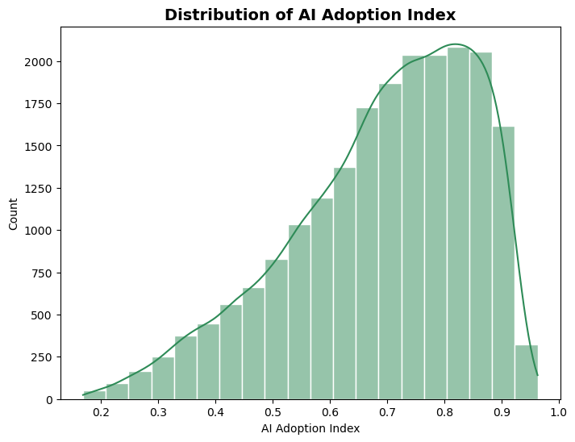

```python
plt.figure(figsize=(8,6))
sns.histplot(df['ai_adoption_index'],color='seagreen',bins=20,edgecolor='white',kde=True)
plt.title("Distribution of AI Adoption Index",fontsize=14,fontweight='bold')
plt.xlabel("AI Adoption Index")
plt.ylabel("Count")
```

### Question 25

Workforce Displacement Distribution

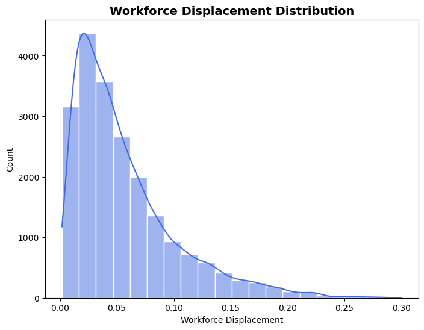

```python
plt.figure(figsize=(8,6))
sns.histplot(df['pct_sector_workforce_displaced'],color='royalblue',bins=20,edgecolor='white',kde=True)
plt.title("Workforce Displacement Distribution",fontsize=14,fontweight='bold')
plt.xlabel("Workforce Displacement")
plt.ylabel("Count")
```

### Question 26

Records by Region

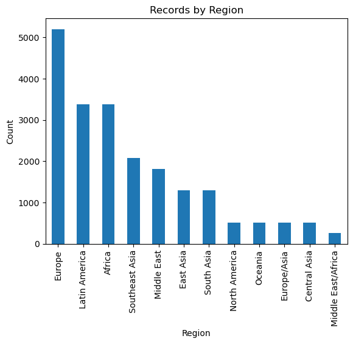

```python
df['region'].value_counts().plot(kind='bar')
plt.title("Records by Region")
plt.xlabel("Region")
plt.ylabel("Count")
```

### Question 27

AI Adoption by Region

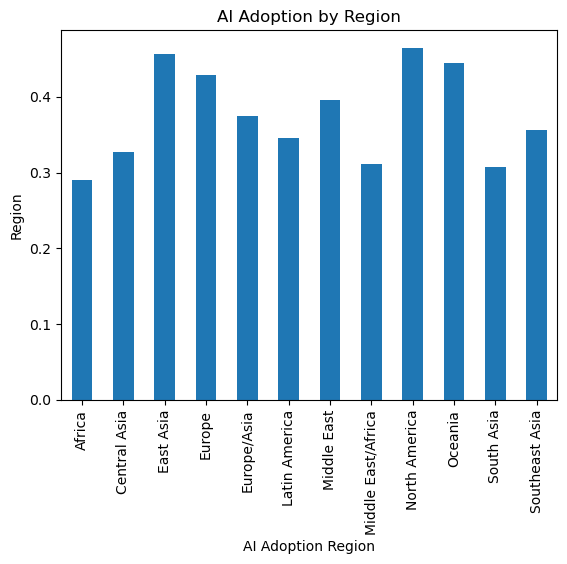

```python
df.groupby('region')['ai_tool_adoption_pct'].mean().plot(kind='bar')
plt.title("AI Adoption by Region")
plt.xlabel("AI Adoption Region")
plt.ylabel("Region")
```

### Question 28

AI Adoption Over Time

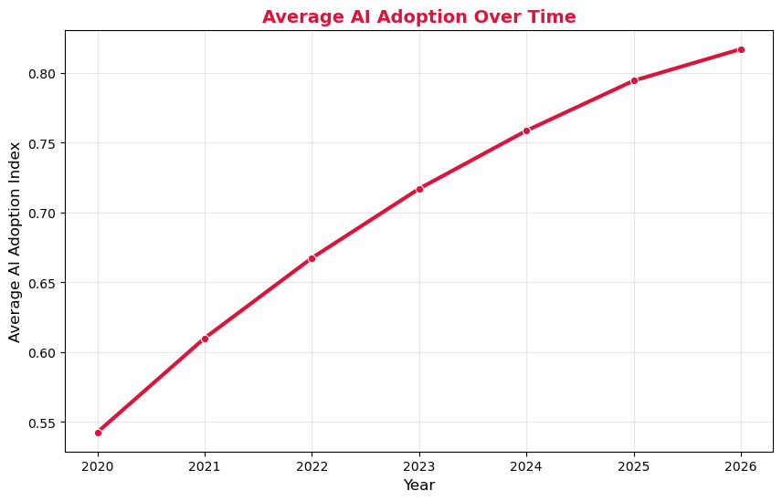

```python
plt.figure(figsize=(10,6))

ai_year = df.groupby('year')['ai_adoption_index'].mean().reset_index()

sns.lineplot(
    data=ai_year,
    x='year',
    y='ai_adoption_index',
    marker='o',
    linewidth=3,
    color='crimson'
)


plt.title('Average AI Adoption Over Time', fontsize=14, fontweight='bold', color='crimson')
plt.xlabel('Year', fontsize=12)
plt.ylabel('Average AI Adoption Index', fontsize=12)
plt.grid(alpha=0.3)
plt.show()
```

### Question 29

Workforce Displacement Over Time

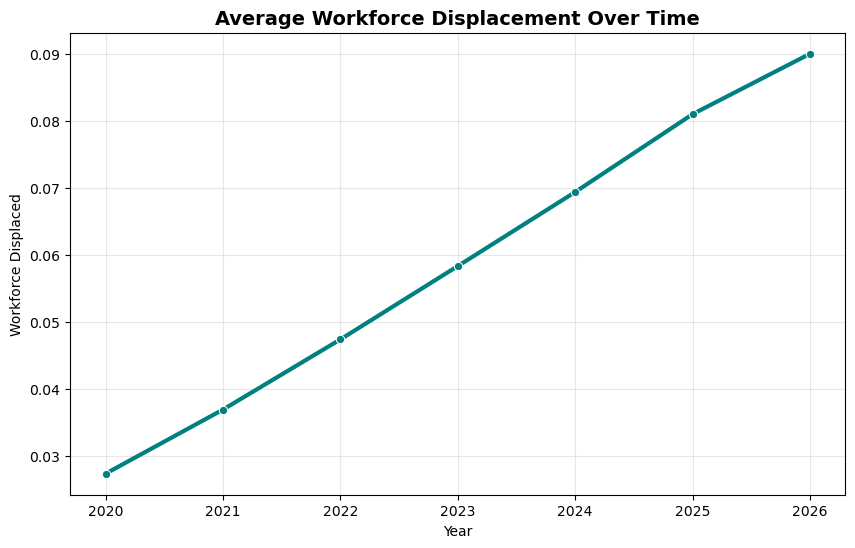

```python
plt.figure(figsize=(10, 6))


workforce = df.groupby('year')['pct_sector_workforce_displaced'].mean().reset_index()


sns.lineplot(
    data=workforce,
    x='year',
    y='pct_sector_workforce_displaced',
    marker='o',
    linewidth=3,
    color='teal'
)


plt.title('Average Workforce Displacement Over Time', fontsize=14, fontweight='bold')
plt.xlabel('Year')
plt.ylabel('Workforce Displaced')


plt.grid(alpha=0.3)
plt.show()
```

### Question 30

Correlation Heatmap

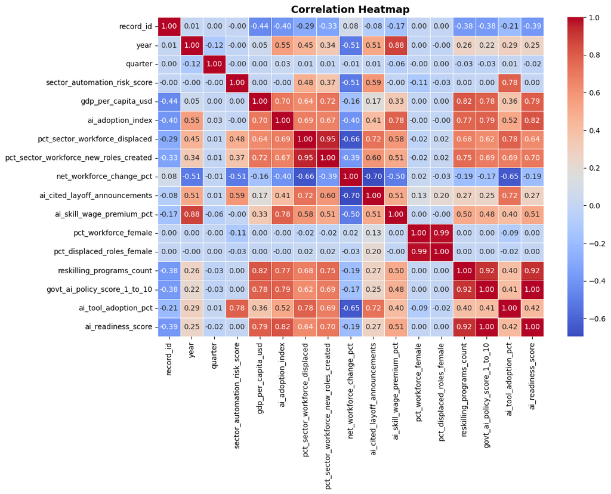

```python
plt.figure(figsize=(12, 8))


corr = df.corr(numeric_only=True)


sns.heatmap(
    corr,
    annot=True,
    cmap='coolwarm',
    linewidths=0.5,
    fmt='.2f'
)


plt.title('Correlation Heatmap', fontsize=14, fontweight='bold')
plt.show()
```

### Question 31

GDP vs AI Adoption

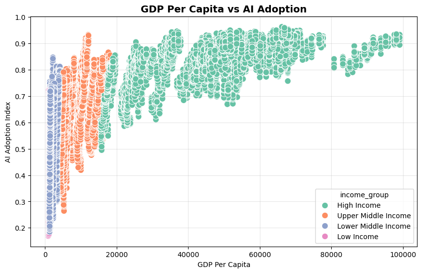

```python
plt.figure(figsize=(10,6))

sns.scatterplot(
    data=df,
    x='gdp_per_capita_usd',
    y='ai_adoption_index',
    hue='income_group',
    palette='Set2',
    s=80
)

plt.title('GDP Per Capita vs AI Adoption',fontsize=14,fontweight='bold')
plt.xlabel('GDP Per Capita')
plt.ylabel('AI Adoption Index')
plt.legend(title='income_group')
plt.grid(alpha=0.3)
plt.show()
```

### Question 32

AI Adoption vs Workforce Displacement - Scatter Plot

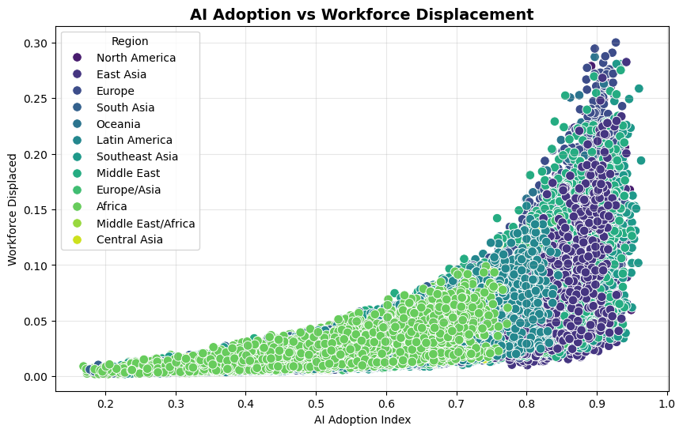

```python
plt.figure(figsize=(10, 6))

sns.scatterplot(
    data=df,
    x='ai_adoption_index',
    y='pct_sector_workforce_displaced',
    hue='region',
    palette='viridis',
    s=70
)


plt.title('AI Adoption vs Workforce Displacement', fontsize=14, fontweight='bold')
plt.xlabel('AI Adoption Index')
plt.ylabel('Workforce Displaced')
plt.legend(title='Region')

plt.grid(alpha=0.3)
plt.show()
```

### Question 33

Workforce Displacement by Industry - boxplot

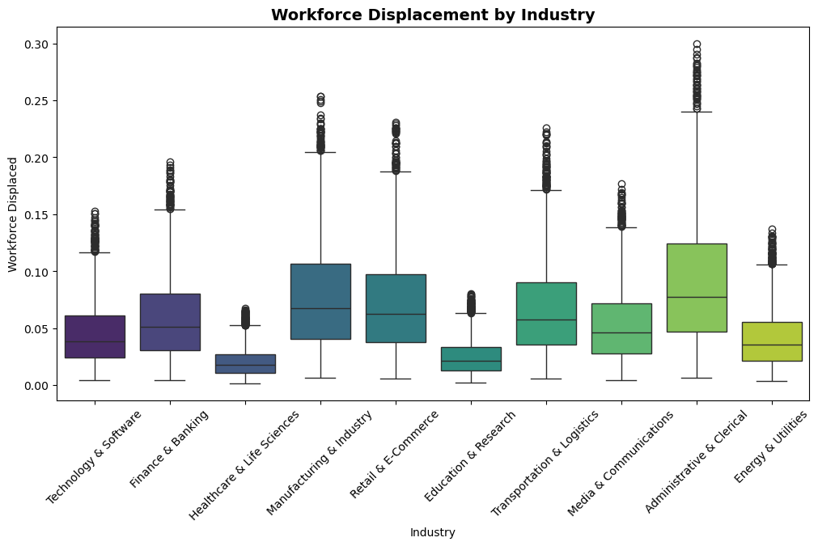

```python
plt.figure(figsize=(12,6))

sns.boxplot(
    data=df,
    x='industry_sector',
    y='pct_sector_workforce_displaced',
    hue='industry_sector',
    palette='viridis',
    legend=False
)

plt.title('Workforce Displacement by Industry', fontsize=14, fontweight='bold')
plt.xlabel('Industry')
plt.ylabel('Workforce Displaced')
plt.xticks(rotation=45)

plt.show()
```

### Question 34

Automation Risk by Industry (Bar Chart)

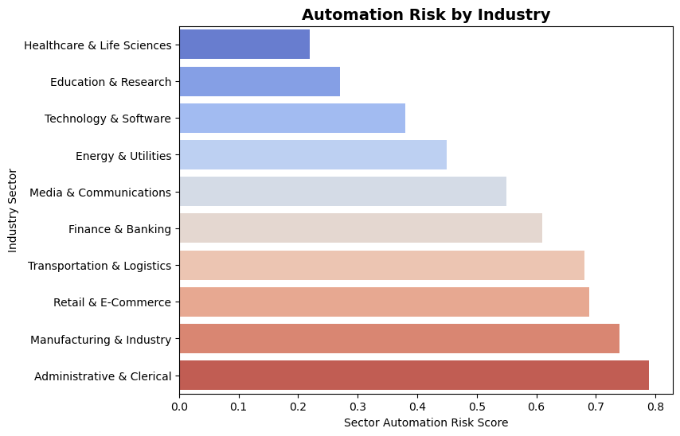

```python
plt.figure(figsize=(8,6))

risk = df.groupby('industry_sector')['sector_automation_risk_score'].mean().sort_values()

sns.barplot(
    data=risk.reset_index(),
    x='sector_automation_risk_score',
    y='industry_sector',
    hue='industry_sector',
    palette='coolwarm',
    legend=False
)

plt.title('Automation Risk by Industry', fontsize=14, fontweight='bold')
plt.xlabel('Sector Automation Risk Score')
plt.ylabel('Industry Sector')

plt.show()
```

### Question 35

Top 10 Countries by AI Adoption

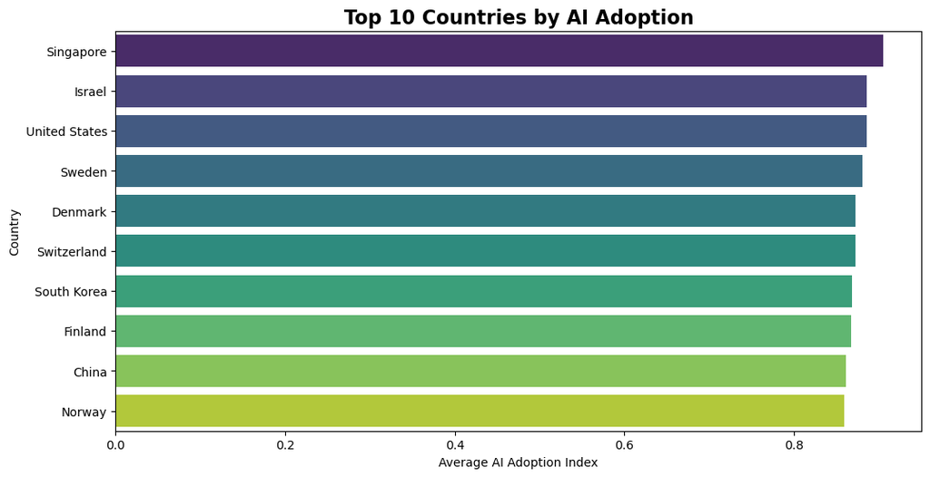

```python
plt.figure(figsize=(12,6))

top10 = df.groupby('country')['ai_adoption_index'].mean().sort_values(ascending=False).head(10)

sns.barplot(
    data=top10.reset_index(),
    x='ai_adoption_index',
    y='country',
    hue='country',
    palette='viridis',
    legend=False
)

plt.title('Top 10 Countries by AI Adoption', fontsize=16, fontweight='bold')
plt.xlabel('Average AI Adoption Index')
plt.ylabel('Country')

plt.show()
```

### Question 36

AI Wage Premium by Income Group

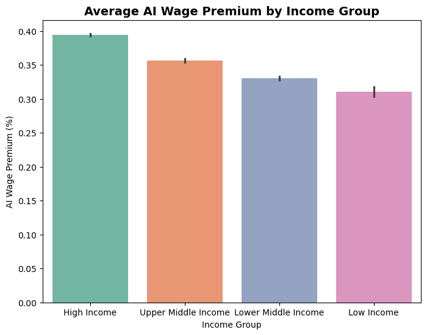

```python
plt.figure(figsize=(8,6))

sns.barplot(
    data=df,
    x='income_group',
    y='ai_skill_wage_premium_pct',
    hue='income_group',
    palette='Set2',
    legend=False
)

plt.title('Average AI Wage Premium by Income Group',
          fontsize=14,
          fontweight='bold')

plt.xlabel('Income Group')
plt.ylabel('AI Wage Premium (%)')

plt.show()
```

### Question 37

Female Workforce vs Female Displacement

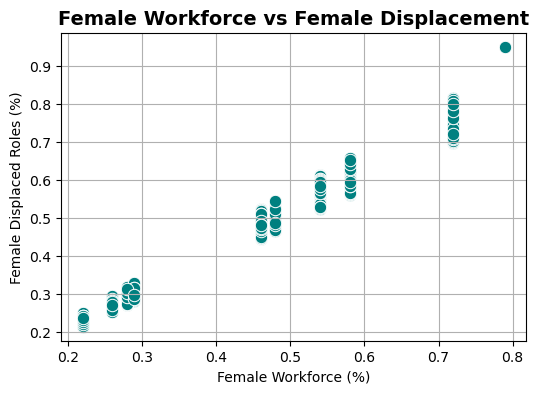

```python
plt.figure(figsize=(6,4))

sns.scatterplot(
    data=df,
    x='pct_workforce_female',
    y='pct_displaced_roles_female',
    color='teal',
    s=80
)

plt.grid(True)

plt.title(
    "Female Workforce vs Female Displacement",
    fontsize=14,
    fontweight='bold'
)

plt.xlabel('Female Workforce (%)')
plt.ylabel('Female Displaced Roles (%)')

plt.show()
```

### Question 38

AI Tool Adoption by Income Group

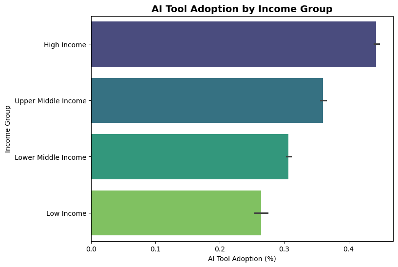

```python
plt.figure(figsize=(8,6))

sns.barplot(
    data=df,
    x='ai_tool_adoption_pct',
    y='income_group',
    hue='income_group',
    palette='viridis',
    legend=False
)

plt.title('AI Tool Adoption by Income Group',
          fontsize=14,
          fontweight='bold')

plt.xlabel('AI Tool Adoption (%)')
plt.ylabel('Income Group')

plt.show()
```